# flotte Tunisair

Iheb Jridi

# **Plan**

## 1- Compréhension métier

## 2- Compréhension des données

## 3- Préparation des données

## 4- Modélisation

## 5- Evaluation

## 6- Conclusion et Perspectives

# **1-Compréhension métier:**

## Business objectives:

##### - Est-ce que la flotte actuelle de Tunisair répond aux exigences internationales ?

##### - Peut-on affirmer que les modéles disponibles dans la compagnie tunisienne joignent les normes standards favorisant la concurrence sur l’échelle régionale et/ou internationale ?

##### - Comment peut-on catégoriser une telle panoplie de modéles d’avions ?

##### - Quel est le profil typique des avions dans le monde ?

## Data Science goals:

#### Etudier les caractéristiques de la flotte Tunisair et des compagnies aériennes internationales.

#### Catégoriser les modèles d’avions.

#### Déterminer le profil standard international des avions.

# **2-Compréhension des données:**

## Importation des données

Dans cette partie, On va utiliser le fichier delta.csv qui nous a été fourni.Ce dernier, regroupe les avions du monde entier appartenant à des compagnies aériennes différentes.

```r
dim(delta)
```

```
## [1] 44 34
```

```
##  [1] "Aircraft"                 "Seat.Width..Club."
##  [3] "Seat.Pitch..Club."        "Seat..Club."
##  [5] "Seat.Width..First.Class." "Seat.Pitch..First.Class."
##  [7] "Seats..First.Class."      "Seat.Width..Business."
##  [9] "Seat.Pitch..Business."    "Seats..Business."
## [11] "Seat.Width..Eco.Comfort." "Seat.Pitch..Eco.Comfort."
## [13] "Seats..Eco.Comfort."      "Seat.Width..Economy."
## [15] "Seat.Pitch..Economy."     "Seats..Economy."
## [17] "Accommodation"            "Cruising.Speed..mph."
## [19] "Range..miles."            "Engines"
## [21] "Wingspan..ft."            "Tail.Height..ft."
## [23] "Length..ft."              "Wifi"
## [25] "Video"                    "Power"
## [27] "Satellite"                "Flat.bed"
## [29] "Sleeper"                  "Club"
## [31] "First.Class"              "Business"
## [33] "Eco.Comfort"              "Economy"
```

```r
str(delta)
```

```
## 'data.frame':    44 obs. of  34 variables:
##  $ Aircraft                : Factor w/ 44 levels "Airbus A319",..: 1 2 3 4 5 6 7 8 9 10 ...
##  $ Seat.Width..Club.       : num  0 19.4 0 0 0 0 0 0 0 0 ...
##  $ Seat.Pitch..Club.       : int  0 44 0 0 0 0 0 0 0 0 ...
##  $ Seat..Club.             : int  0 12 0 0 0 0 0 0 0 0 ...
##  $ Seat.Width..First.Class.: num  21 19.4 21 21 0 0 0 0 19.6 21 ...
##  $ Seat.Pitch..First.Class.: num  36 40 36 36 0 0 0 0 37 37 ...
##  $ Seats..First.Class.     : int  12 28 12 12 0 0 0 0 12 12 ...
##  $ Seat.Width..Business.   : num  0 21 0 0 21 21 21 20 0 0 ...
##  $ Seat.Pitch..Business.   : num  0 59 0 0 60 80 80 60 0 0 ...
##  $ Seats..Business.        : int  0 14 0 0 32 34 34 34 0 0 ...
##  $ Seat.Width..Eco.Comfort.: num  17.2 0 17.2 17.2 18 18 18 18 18.1 17.2 ...
##  $ Seat.Pitch..Eco.Comfort.: num  34 0 34 34 35 35 35 35 34 34 ...
##  $ Seats..Eco.Comfort.     : int  18 0 18 18 30 32 32 32 15 18 ...
##  $ Seat.Width..Economy.    : num  17.2 0 17.2 17.2 18 18 18 18 18.1 17.2 ...
```

[output cut: 20 more lines]

### Les mots clés:

#### Dans cette partie on va présenter une petite explication des differentes variables de notre fichier delta.csv.

##### “Seat.Width..Club.” : c’est la largueur des sieges dans un club.

##### “Seat.Pitch..Club.” : c’est la hauteur des sieges dans un club.

##### “Seat..Club.” : c’est le nombre de sieges dans un club.

##### “Seat.Width..First.Class.” : c’est la largueur des sieges dans la Premier Classe.

##### “Seat.Pitch..First.Class.”: c’est la hauteur des sieges dans la Premier Classe.

##### “Seats..First.Class.” : c’est le nombre de sieges dans la Premier Classe.

##### “Seat.Width..Business.” : c’est la largueur des sieges dans la Classe Affaire.

##### “Seat.Pitch..Business.” c’est la hauteur des sieges dans la Classe Affaire.

##### “Seats..Business.” : c’est le nombre de sieges dans la Classe Affaire.

##### “Seat.Width..Eco.Comfort.” : c’est la largueur des sieges dans la Classe Eco Confort.

##### “Seat.Pitch..Eco.Comfort.”: c’est la hauteur des sieges dans la Classe Eco Confort.

##### “Seats..Eco.Comfort.” : c’est le nombre de sieges dans la Classe Eco Confort.

##### “Seat.Width..Economy.” : c’est la largueur des sieges dans la Classe Economique.

##### “Seat.Pitch..Economy.” c’est la hauteur des sieges dans la Classe Economique.

##### “Seats..Economy.” : c’est le nombre de sieges dans la Classe Economique.

##### “Accommodation”: c’est le nombre de siege total.

##### “Cruising.Speed..mph.” : c’est la vitesse de croisiere.

##### “Range..miles.” :c’est la distance parcourue.

##### “Engines” : c’est le nombre de moteur

##### “Wingspan..ft.” : c’est l’envergure,

##### “Tail.Height..ft.” : c’est la hauteur de l’empennage arrière.

##### “Length..ft.” : c’est la longueur.

##### “Wifi” : si l’avion dispose du wifi alors 1:oui sinon 0:non

##### “Video” : si l’avion dispose de lecteur video alors 1:oui sinon 0:non

##### “Power” : si l’avion dispose de charge alors 1:oui sinon 0:non

##### “Satellite” : si l’avion dispose d’un satellite alors 1:oui sinon 0:non

##### “Flat.bed” : si l’avion dispose de siege ajustable alors 1:oui sinon 0:non

##### “Sleeper” : si l’avion dispose de cabine personnelle alors 1:oui sinon 0:non

##### “Club” : si l’avion dispose d’un club alors 1:oui sinon 0:non

##### “First.Class” : si l’avion dispose d’une Premiere Classe alors 1:oui sinon 0:non

##### “Business” : si l’avion dispose d’une Classe Affaire alors 1:oui sinon 0:non

##### “Eco.Comfort” : si l’avion dispose d’une Classe Eco Confort alors 1:oui sinon 0:non

##### “Economy” : si l’avion dispose d’une Classe Economique alors 1:oui sinon 0:non

### Extraction des données de tunisair:

```r
tn = delta[which((delta$Aircraft == "Airbus A319")|(delta$Aircraft == "Airbus A330-200")|(delta$Aircraft == "Airbus A320")|(delta$Aircraft == "Boeing 737-700 (73W)")),]
tn
```

```
##                Aircraft Seat.Width..Club. Seat.Pitch..Club. Seat..Club.
## 1           Airbus A319                 0                 0           0
## 3           Airbus A320                 0                 0           0
## 5       Airbus A330-200                 0                 0           0
## 10 Boeing 737-700 (73W)                 0                 0           0
##    Seat.Width..First.Class. Seat.Pitch..First.Class. Seats..First.Class.
## 1                        21                       36                  12
## 3                        21                       36                  12
## 5                         0                        0                   0
## 10                       21                       37                  12
##    Seat.Width..Business. Seat.Pitch..Business. Seats..Business.
## 1                      0                     0                0
## 3                      0                     0                0
## 5                     21                    60               32
## 10                     0                     0                0
```

[output cut: 25 more lines]

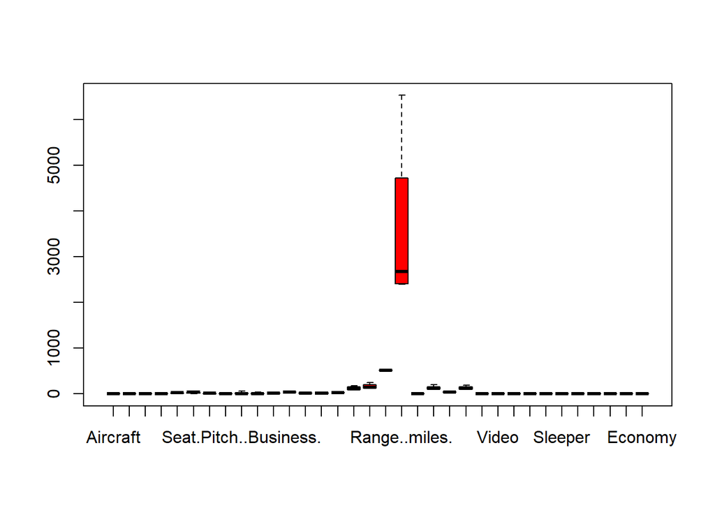

```r
boxplot(tn,col="red")
```

On peut remarqué que les variables prennent des valeurs très différentes.

```r
business=tn[which(tn$Seats..Business.>0),]
business$Aircraft
```

```
## [1] Airbus A330-200
## 44 Levels: Airbus A319 Airbus A319 VIP Airbus A320 ... MD-DC9-50
```

On remarque que l’Airbus A330-200 est le seul type d’avion de Tunisair qui a une Classe Affaire .

```r
avionVPS=tn[which(tn$Video>0 & tn$Power>0 & tn$Satellite>0 ),]
avionVPS$Aircraft
```

```
## [1] Boeing 737-700 (73W)
## 44 Levels: Airbus A319 Airbus A319 VIP Airbus A320 ... MD-DC9-50
```

On remarque que L’Airbus Boeing 737-700 est le seul avion de Tunisair qui a des ecrans video, power et satellite.

```r
economy=tn[which(tn$Seats..Economy.>0),]
economy$Aircraft
```

```
## [1] Airbus A319          Airbus A320          Airbus A330-200
## [4] Boeing 737-700 (73W)
## 44 Levels: Airbus A319 Airbus A319 VIP Airbus A320 ... MD-DC9-50
```

L’Airbus A319, L’Airbus A320,L’Airbus A330-200 et Boeing 737-700 (73W) sont les avions qui possedent des Classes Economiques.

```r
economy[(which.max(economy$Seats..Economy.)),]
```

```
##          Aircraft Seat.Width..Club. Seat.Pitch..Club. Seat..Club.
## 5 Airbus A330-200                 0                 0           0
##   Seat.Width..First.Class. Seat.Pitch..First.Class. Seats..First.Class.
## 5                        0                        0                   0
##   Seat.Width..Business. Seat.Pitch..Business. Seats..Business.
## 5                    21                    60               32
##   Seat.Width..Eco.Comfort. Seat.Pitch..Eco.Comfort. Seats..Eco.Comfort.
## 5                       18                       35                  30
##   Seat.Width..Economy. Seat.Pitch..Economy. Seats..Economy. Accommodation
## 5                   18                 30.5             181           243
##   Cruising.Speed..mph. Range..miles. Engines Wingspan..ft.
## 5                  531          6536       2        197.83
##   Tail.Height..ft. Length..ft. Wifi Video Power Satellite Flat.bed Sleeper
## 5            59.83      188.67    0     1     1         0        1       0
##   Club First.Class Business Eco.Comfort Economy
## 5    0           0        1           1       1
```

l’Airbus A330-200 est l’avion qui comporte le plus de sieges dans sa Classe Economie.

```r
tn[which.max(tn$Accommodation),]
```

```
##          Aircraft Seat.Width..Club. Seat.Pitch..Club. Seat..Club.
## 5 Airbus A330-200                 0                 0           0
##   Seat.Width..First.Class. Seat.Pitch..First.Class. Seats..First.Class.
## 5                        0                        0                   0
##   Seat.Width..Business. Seat.Pitch..Business. Seats..Business.
## 5                    21                    60               32
##   Seat.Width..Eco.Comfort. Seat.Pitch..Eco.Comfort. Seats..Eco.Comfort.
## 5                       18                       35                  30
##   Seat.Width..Economy. Seat.Pitch..Economy. Seats..Economy. Accommodation
## 5                   18                 30.5             181           243
##   Cruising.Speed..mph. Range..miles. Engines Wingspan..ft.
## 5                  531          6536       2        197.83
##   Tail.Height..ft. Length..ft. Wifi Video Power Satellite Flat.bed Sleeper
## 5            59.83      188.67    0     1     1         0        1       0
##   Club First.Class Business Eco.Comfort Economy
## 5    0           0        1           1       1
```

l’Airbus A330-200, est l’avion qui comporte le plus nombre de siéges.

```r
mean(tn$Cruising.Speed..mph.)
```

```
## [1] 520.5
```

On remarque que la vitesse moyenne des avions de Tunisair est de 520.5 mph

```r
mean(tn$Range..miles.)
```

```
## [1] 3570
```

On remarque que La distance moyenne des avions de Tunisair est de 3570 miles

### Exploration graphique des données de Tunisaire

```r
library(FactoMineR)
tunisairacp=PCA(tn[,c(2:34)],quanti.sup=22:33)
```

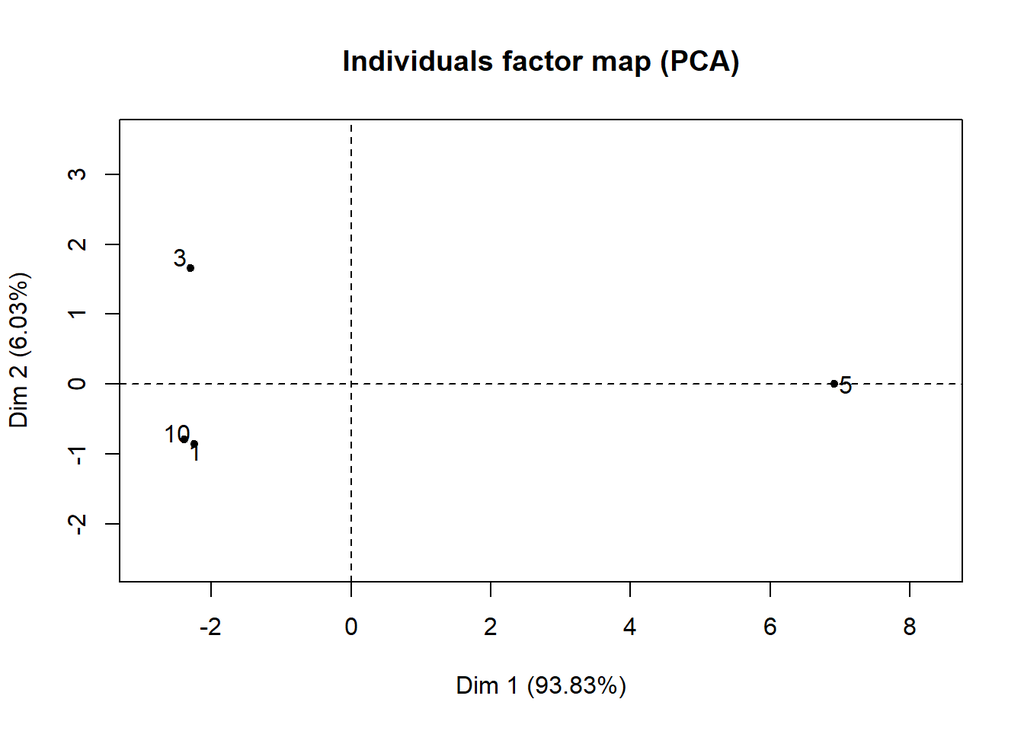

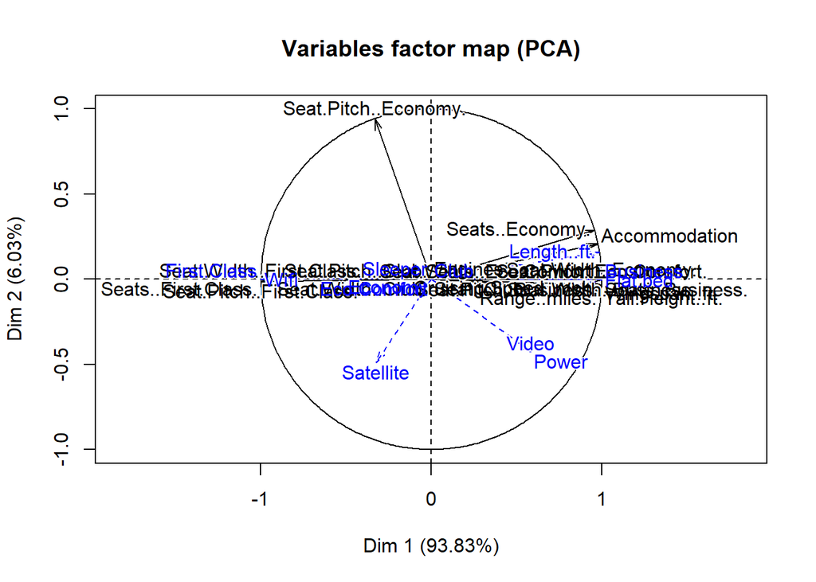

On remarque que la panoplie en Economy class et en Business Class est importante ,Moyenne panoplie en Accomodation, Wingspan et Faible panoplie en Vidéo,Sleeper, Power, Satellite et Flat-bed et First.Class.

Pour étudier l’exigence de l’âge on va extraire des données à partir de https://www.airfleets.fr

```r
library('rvest') #Scraping
```

```r
library('stringr')# Manipulation des chaines de caractères
library('ggplot2')

# L'age et le classement d'age des avions de Tunisair
url_tun <- 'https://www.airfleets.fr/ageflotte/tunisair.html'

webpage_tun <- read_html(url_tun)
age_data_html_tun <- html_nodes(webpage_tun,'.soustitre+ table table td')

#Converting the ranking data to text
age_data_tun <- html_text(age_data_html_tun)
a = as.data.frame(matrix(age_data_tun[-1:-4],ncol = 4,byrow = T))
colnames(a) <- age_data_tun[1:4]
a
```

```
##                     Appareil Nombre      Age
## 1                Airbus A319      2 14.3 ans
## 2                Airbus A320     14 15.7 ans
## 3                Airbus A330      2  3.4 ans
## 4                 Boeing 737      1 28.6 ans
## 5        Boeing 737 Next Gen      6 18.7 ans
## 6 McDonnell Douglas MD-80/90      1 28.5 ans
## 7                      TOTAL     26 16.3 ans
##                                                                   Position pour l'age par type d'appareil
## 1                                   Sur 140 compagnies opérant ce type d'appareil Tunisair est numéro 101
## 2                                   Sur 259 compagnies opérant ce type d'appareil Tunisair est numéro 190
## 3                                    Sur 129 compagnies opérant ce type d'appareil Tunisair est numéro 15
## 4                                   Sur 213 compagnies opérant ce type d'appareil Tunisair est numéro 159
## 5                                   Sur 249 compagnies opérant ce type d'appareil Tunisair est numéro 238
## 6                                     Sur 39 compagnies opérant ce type d'appareil Tunisair est numéro 24
## 7 Le calcul de l'age de la flotte peut être tronqué car il est seulement basé sur les appareils supportés
```

Pour étudier la concurrence de Tunisair sur l’échelle régionale et affirmer que les modèles disponibles dans la compagnie tunisienne joignent les normes standards on a converti un fichier fleetdata.csv à partir de cette source https://www.kaggle.com/traceyvanp/airlinefleet/data en un fichier fleetdata.xlsx.

# **3-Préparation des données:**

Pour appliquer la modelisation,il est necessaire de transformer toutes les variables qualitatives en des variables quantitatives. En effet, on a ajusté nos données avec la méthode SCALE.

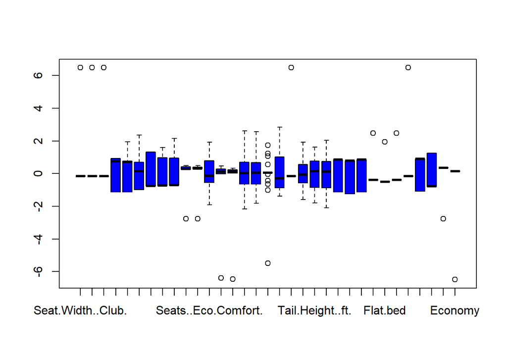

```r
scaled_data = as.matrix(scale(delta[,c(2:34)]))
set.seed(123)
boxplot(scaled_data , col="blue")
```

Dans cette phase, on va construire une data frame qui englobe Tunisair et les autres compagnies comme: Lufthansa,KLM,Egyptair … afin d’avoir une vision sur l’age des avions de la flotte de Tunisair par rapport aux autres compagnies.

```r
#liste des compagnies à comparer avec Tunisair
companies <- c("lufthansa","klm","delta%20air%20lines","air%20france","egyptair")

liste_age = list()
for (i in companies){
url <- paste('https://www.airfleets.fr/ageflotte/',i,'.html',sep = "")

webpage <- read_html(url)
age_data_html <- html_nodes(webpage,'.soustitre+ table table td')

#Converting the ranking data to text
age_data <- html_text(age_data_html)
age_comp <- as.data.frame(matrix(age_data[-1:-4],ncol = 4,byrow = T),stringsAsFactors = F)
colnames(age_comp) <- age_data[1:4]
liste_age <- append(liste_age,as.data.frame(age_comp))


}
#Conversion des listes dans des data frame
lufthansa <- as.data.frame(liste_age[1:4])
klm <- as.data.frame(liste_age[5:8])
delta1 <- as.data.frame(liste_age[9:12])
air_france <- as.data.frame(liste_age[13:16])
egyptair <- as.data.frame(liste_age[17:20])

#labélisation des dataframe
tunisair<-cbind(a,Label = rep("tunisair", times = 7))
lufthansa <- cbind(lufthansa,Label = rep("lufthansa",times = 11))
klm <- cbind(klm,Label = rep("klm", times = 6))
delta1 <- cbind(delta1,Label = rep("delta1", times = 12))
air_france <- cbind(air_france,Label = rep("air_france",times = 10))
egyptair <- cbind(egyptair, Label = rep("egyptair", times = 7))
colnames(tunisair) <- colnames(lufthansa)

#unification des données
df_age <- as.data.frame(rbind(lufthansa,klm,delta1,air_france,egyptair,tunisair))
#conversion d'age et nombre en numeric
df_age$Age <- as.numeric(gsub("[a-zA-Z ]", "", df_age$Age))
df_age$Nombre <-as.numeric(df_age$Nombre)

df_age
```

```
##                      Appareil Nombre  Age
## 1                 Airbus A319      7 16.6
## 2                 Airbus A320     11 10.7
## 3                 Airbus A321     10 13.6
## 4                 Airbus A330      4 11.3
## 5                 Airbus A340      5 15.3
## 6                 Airbus A350      1  0.9
## 7                 Airbus A380      3  6.9
## 8                  Boeing 747      8 10.8
## 9                  Boeing 777      9  4.4
## 10    McDonnell Douglas MD-11      2 19.1
## 11                      TOTAL      6 12.1
## 12                Airbus A330     13  9.4
## 13        Boeing 737 Next Gen     15 11.8
## 14                 Boeing 747     14 21.9
```

[output cut: 147 more lines]

## **4- Modélisation:**

### Plot des nombres d’avions par compagnie:

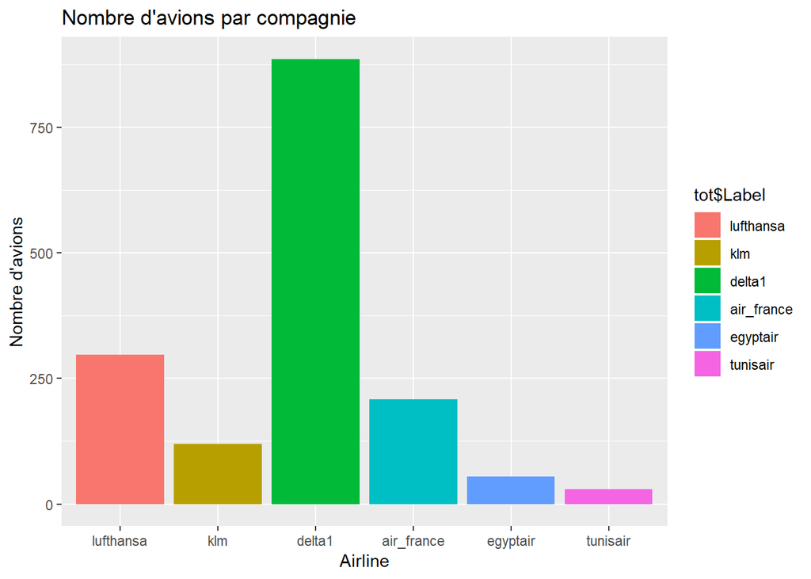

```r
tot <- df_age[which(df_age$Appareil =="TOTAL"),]

tot %>% ggplot(aes(x = .$Label, y =c(297,120,886,208,55,29)  ))+
  geom_col(aes(fill=tot$Label)) +
  labs(title = "Nombre d'avions par compagnie",x = "Airline", y = "Nombre d'avions",colour = "Label")
```

On remarque que l’effectif de la flotte de Tunisair est peu nombreux par rapport à Delta (886 avions). Et régionalement Egyptair a presque deux fois le nombre d’avions que Tunisair.

## Plot des moyenne d’age par compagnie

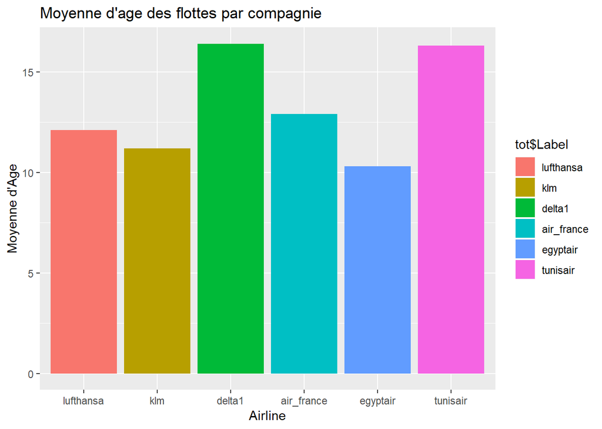

```r
tot %>% ggplot(aes(x = .$Label, y = .$Age)) +
  geom_col(aes(fill=tot$Label)) +
  labs(title = "Moyenne d'age des flottes par compagnie",x = "Airline", y = "Moyenne d'Age",colour = "Label")
```

Ici, la moyenne d’age de la flotte de Tunisair est relativement haute par rapport aux autres compagnies.Mais ça reste dans les normes en considérant l’effectif et la diversité d’autres compagnies.

## Plot des classement pour Tunisair par modèle:

```r
classement <- list()
#extraction des classement
classement <- str_extract_all(tunisair$Position.pour.l.age.par.type.d.appareil, "[0-9]+")[-7]
nb_total_modele <- vector()
classement_modele <- vector()
for (i in 1:6 )
{
  nb_total_modele <- c(nb_total_modele,classement[[i]][1])
  classement_modele <- c(classement_modele,classement[[i]][2])
}


# Dataframe représentant le classement de chaque avions par age
tunisair_df <- as.data.frame(cbind(nb_total = nb_total_modele,classemeent = classement_modele))
tunisair_df$nb_total <- as.numeric(as.character(tunisair_df$nb_total))
tunisair_df$classemeent <- as.numeric(as.character(tunisair_df$classemeent))
tunisair_df
```

```
##   nb_total classemeent
## 1      140         101
## 2      259         190
## 3      129          15
## 4      213         159
## 5      249         238
## 6       39          24
```

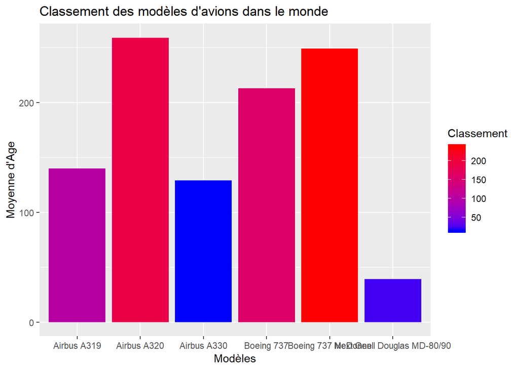

```r
#Plot
tunisair_df %>%ggplot(aes(x = tunisair$Appareil[-7], y =tunisair_df$nb_total,fill = .$classemeent)) +
  geom_col()+
  scale_fill_gradient(name = "Classement",low = "blue", high = "red")+
  labs(title = "Classement des modèles d'avions dans le monde",x = "Modèles", y = "Moyenne d'Age",colour = "Label")
```

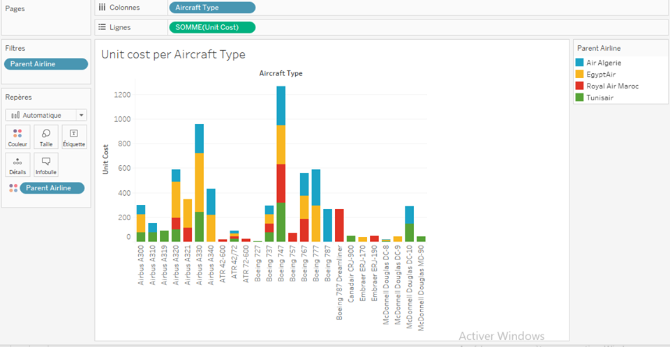

#### Number of planes per Aircraft Type:

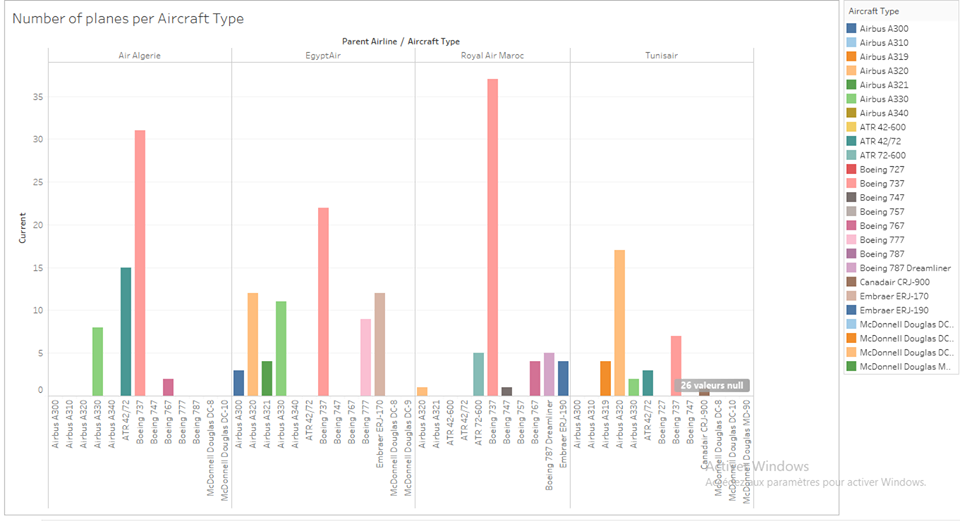

A partir de ce tableau on peut trouver le nombre d’avions disponibles pour chaque modèle d’avion pour chaque compagnie. En calculant le nombre d’avions disponibles pour chaque compagnie (c’est la somme des avions de chaque modèle appartenant à sa compagnie), on a pu constater que qune le nombre d’avions pour la compagnie Tunisair est :33,le nombre d’avions pour la compagnie air Algérie est: 56, Le nombre d’avions pour la compagnie Royal Maroc est :57, le nombre d’avions pour la compagnie Egypte air:73. On peut conclure que Tunisair possède un nombre d’avions limité par rapport les autres compagnies régionale.

### K-means

Dans cette partie,on a utilisé k-means.En effet, K-means nécéssite une connaisance de paramètre k ( le nombre de cluster) on essaye donc de trouver le nombre optimal de clusters et on a choisi de repeter ce processus 15 fois.

```r
k.max <- 15
data <- scaled_data
wss <- sapply(1:k.max,
              function(k){kmeans(data, k, nstart=50,iter.max = 15 )$tot.withinss})
wss
```

```
##  [1] 1419.00000  905.99507  568.42306  350.58923  282.30810  226.57809
##  [7]  177.96180  146.17136  120.07790  100.68132   89.71982   70.11518
## [13]   55.91691   46.45507   50.36478
```

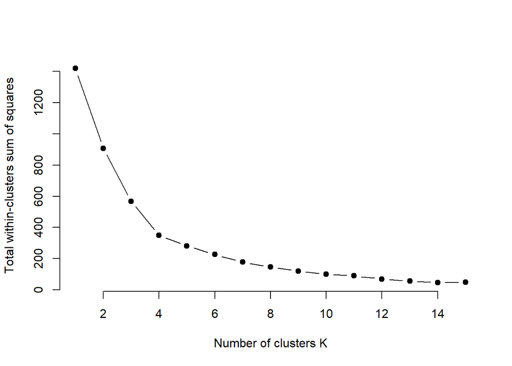

```r
plot(1:k.max, wss,
     type="b", pch = 19, frame = FALSE,
     xlab="Number of clusters K",
     ylab="Total within-clusters sum of squares")
```

```r
grp_delta = kmeans(delta[,c(2:34)],centers = 3)
grp_delta
```

```
## K-means clustering with 3 clusters of sizes 15, 15, 14
##
## Cluster means:
##   Seat.Width..Club. Seat.Pitch..Club. Seat..Club. Seat.Width..First.Class.
## 1          1.293333          2.933333         0.8                17.760000
## 2          0.000000          0.000000         0.0                14.706667
## 3          0.000000          0.000000         0.0                 1.321429
##   Seat.Pitch..First.Class. Seats..First.Class. Seat.Width..Business.
## 1                33.166667           19.333333               4.20000
## 2                26.933333            9.200000               0.00000
## 3                 4.285714            2.571429              19.21429
##   Seat.Pitch..Business. Seats..Business. Seat.Width..Eco.Comfort.
## 1              10.10000         3.733333                 16.14667
## 2               0.00000         0.000000                 13.00667
## 3              69.48214        33.285714                 17.96429
##   Seat.Pitch..Eco.Comfort. Seats..Eco.Comfort. Seat.Width..Economy.
## 1                 31.96667            20.06667             16.14667
## 2                 25.00000            10.46667             17.68000
## 3                 35.07143            33.00000             17.96429
##   Seat.Pitch..Economy. Seats..Economy. Accommodation Cruising.Speed..mph.
## 1             29.00000        134.1333     175.66667             517.0000
## 2             31.13333         75.6000      95.26667             502.1333
## 3             31.14286        182.7857     251.85714             529.0714
##   Range..miles.  Engines Wingspan..ft. Tail.Height..ft. Length..ft.
## 1      3375.000 2.000000     129.25467         43.86113    146.1329
## 2      1661.467 2.000000      89.12047         28.72687    111.8436
## 3      6763.000 2.142857     181.21314         56.03133    194.8447
##        Wifi     Video     Power Satellite  Flat.bed    Sleeper       Club
## 1 0.9333333 0.8666667 0.5333333       0.4 0.0000000 0.06666667 0.06666667
## 2 0.7333333 0.0000000 0.2000000       0.0 0.0000000 0.00000000 0.00000000
## 3 0.0000000 1.0000000 1.0000000       0.0 0.6428571 0.35714286 0.00000000
##   First.Class Business Eco.Comfort   Economy
## 1   0.8666667      0.2   0.9333333 0.9333333
## 2   0.7333333      0.0   0.7333333 1.0000000
## 3   0.0000000      1.0   1.0000000 1.0000000
##
## Clustering vector:
##  [1] 2 1 2 2 3 3 3 3 2 1 1 1 1 3 1 1 1 1 1 1 1 1 3 3 1 1 3 3 3 3 3 3 3 2 2
## [36] 2 2 2 2 2 2 2 2 2
##
## Within cluster sum of squares by cluster:
## [1]  4714287  3744189 21951741
##  (between_SS / total_SS =  86.5 %)
##
## Available components:
##
## [1] "cluster"      "centers"      "totss"        "withinss"
## [5] "tot.withinss" "betweenss"    "size"         "iter"
## [9] "ifault"
```

```r
c=table(delta$Aircraft , grp_delta$cluster)
c
```

```
##
##                                1 2 3
##   Airbus A319                  0 1 0
##   Airbus A319 VIP              1 0 0
##   Airbus A320                  0 1 0
##   Airbus A320 32-R             0 1 0
##   Airbus A330-200              0 0 1
##   Airbus A330-200 (3L2)        0 0 1
##   Airbus A330-200 (3L3)        0 0 1
##   Airbus A330-300              0 0 1
##   Boeing 717                   0 1 0
##   Boeing 737-700 (73W)         1 0 0
##   Boeing 737-800 (738)         1 0 0
##   Boeing 737-800 (73H)         1 0 0
##   Boeing 737-900ER (739)       1 0 0
##   Boeing 747-400 (74S)         0 0 1
##   Boeing 757-200 (757)         1 0 0
##   Boeing 757-200 (75A)         1 0 0
##   Boeing 757-200 (75E)         1 0 0
##   Boeing 757-200 (75M)         1 0 0
##   Boeing 757-200 (75N)         1 0 0
##   Boeing 757-200 (75V)         1 0 0
##   Boeing 757-200 (75X)         1 0 0
##   Boeing 757-300               1 0 0
##   Boeing 767-300 (76G)         0 0 1
##   Boeing 767-300 (76L)         0 0 1
##   Boeing 767-300 (76P)         1 0 0
##   Boeing 767-300 (76Q)         1 0 0
##   Boeing 767-300 (76T)         0 0 1
##   Boeing 767-300 (76U)         0 0 1
##   Boeing 767-300 (76Z V.1)     0 0 1
##   Boeing 767-300 (76Z V.2)     0 0 1
##   Boeing 767-400 (76D)         0 0 1
##   Boeing 777-200ER             0 0 1
##   Boeing 777-200LR             0 0 1
##   CRJ 100/200 ExpressJet       0 1 0
##   CRJ 100/200 Pinnacle/SkyWest 0 1 0
##   CRJ 700                      0 1 0
##   CRJ 900                      0 1 0
##   E120                         0 1 0
##   E170                         0 1 0
##   E175                         0 1 0
##   ERJ-145                      0 1 0
##   MD-88                        0 1 0
##   MD-90                        0 1 0
##   MD-DC9-50                    0 1 0
```

```r
d=table(grp_delta$cluster)
d
```

```
##
##  1  2  3
## 15 15 14
```

```r
print(grp_delta)
```

```
## K-means clustering with 3 clusters of sizes 15, 15, 14
##
## Cluster means:
##   Seat.Width..Club. Seat.Pitch..Club. Seat..Club. Seat.Width..First.Class.
## 1          1.293333          2.933333         0.8                17.760000
## 2          0.000000          0.000000         0.0                14.706667
## 3          0.000000          0.000000         0.0                 1.321429
##   Seat.Pitch..First.Class. Seats..First.Class. Seat.Width..Business.
## 1                33.166667           19.333333               4.20000
## 2                26.933333            9.200000               0.00000
## 3                 4.285714            2.571429              19.21429
##   Seat.Pitch..Business. Seats..Business. Seat.Width..Eco.Comfort.
## 1              10.10000         3.733333                 16.14667
## 2               0.00000         0.000000                 13.00667
## 3              69.48214        33.285714                 17.96429
##   Seat.Pitch..Eco.Comfort. Seats..Eco.Comfort. Seat.Width..Economy.
## 1                 31.96667            20.06667             16.14667
## 2                 25.00000            10.46667             17.68000
## 3                 35.07143            33.00000             17.96429
##   Seat.Pitch..Economy. Seats..Economy. Accommodation Cruising.Speed..mph.
## 1             29.00000        134.1333     175.66667             517.0000
## 2             31.13333         75.6000      95.26667             502.1333
## 3             31.14286        182.7857     251.85714             529.0714
##   Range..miles.  Engines Wingspan..ft. Tail.Height..ft. Length..ft.
## 1      3375.000 2.000000     129.25467         43.86113    146.1329
## 2      1661.467 2.000000      89.12047         28.72687    111.8436
## 3      6763.000 2.142857     181.21314         56.03133    194.8447
##        Wifi     Video     Power Satellite  Flat.bed    Sleeper       Club
## 1 0.9333333 0.8666667 0.5333333       0.4 0.0000000 0.06666667 0.06666667
## 2 0.7333333 0.0000000 0.2000000       0.0 0.0000000 0.00000000 0.00000000
## 3 0.0000000 1.0000000 1.0000000       0.0 0.6428571 0.35714286 0.00000000
##   First.Class Business Eco.Comfort   Economy
## 1   0.8666667      0.2   0.9333333 0.9333333
## 2   0.7333333      0.0   0.7333333 1.0000000
## 3   0.0000000      1.0   1.0000000 1.0000000
##
## Clustering vector:
##  [1] 2 1 2 2 3 3 3 3 2 1 1 1 1 3 1 1 1 1 1 1 1 1 3 3 1 1 3 3 3 3 3 3 3 2 2
## [36] 2 2 2 2 2 2 2 2 2
##
## Within cluster sum of squares by cluster:
## [1]  4714287  3744189 21951741
##  (between_SS / total_SS =  86.5 %)
##
## Available components:
##
## [1] "cluster"      "centers"      "totss"        "withinss"
## [5] "tot.withinss" "betweenss"    "size"         "iter"
## [9] "ifault"
```

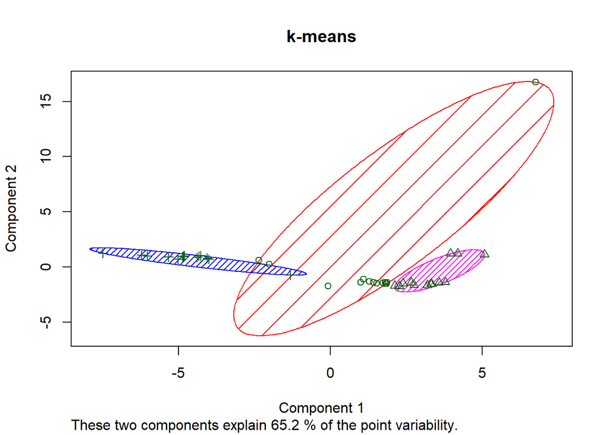

```r
library(cluster)
 clusplot(delta[,c(2:34)], grp_delta$cluster, lines = 0, color= T, shade= T,
         main = paste('k-means'))
```

### CAH

La classification ascendante hiérarchique (CAH): son principe est de rassembler des individus selon un critère de ressemblance défini au préalable qui s’exprimera sous la forme d’une matrice de distances, exprimant la distance existant entre chaque individu pris deux à deux. Deux observations identiques auront une distance nulle. Plus les deux observations seront dissemblables, plus la distance sera importante.

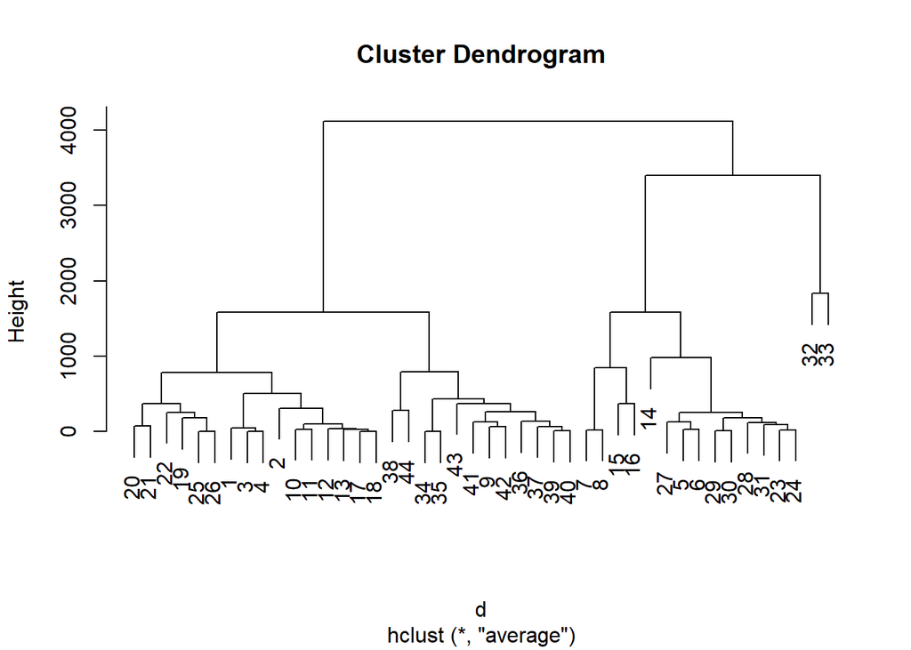

```r
d <- dist(delta[,c(2:34)], method = "euclidean")
hc <- hclust(d , method = "average")
plot (hc)
```

```r
gpe_cah = cutree(hc ,3)
table(gpe_cah)
```

```
## gpe_cah
##  1  2  3
## 28 14  2
```

```r
print(gpe_cah)
```

```
##  [1] 1 1 1 1 2 2 2 2 1 1 1 1 1 2 2 2 1 1 1 1 1 1 2 2 1 1 2 2 2 2 2 3 3 1 1
## [36] 1 1 1 1 1 1 1 1 1
```

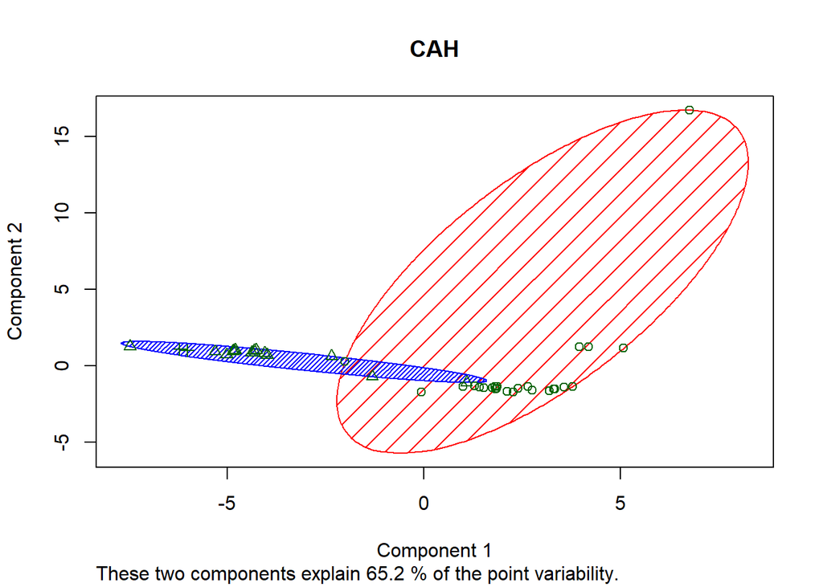

```r
library(cluster)
 clusplot(delta[,c(2:34)], gpe_cah,  lines = 0, color= T, shade= T,
         main = paste('CAH'))
```

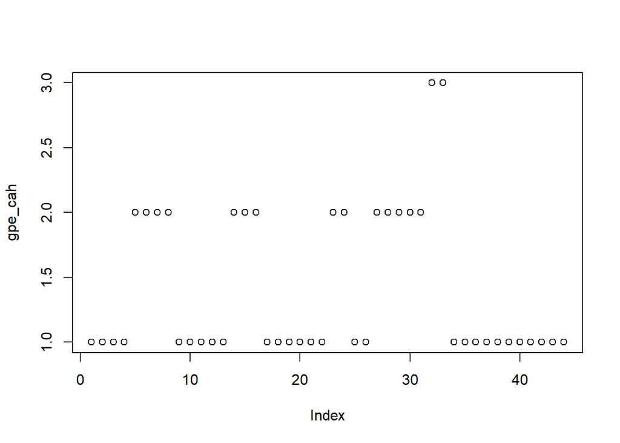

```r
plot(gpe_cah)
```

### PAM :

similaire à K-means, car les deux sont des algorithmes qui consiste à segmenter l’ensemble de données en groupes

```r
library("cluster")
gpe_pam <- pam(delta[,c(2:34)], 3)
print (gpe_pam)
```

[output not shown]

```r
table(gpe_pam$clustering)
```

```
##
##  1  2  3
## 17 15 12
```

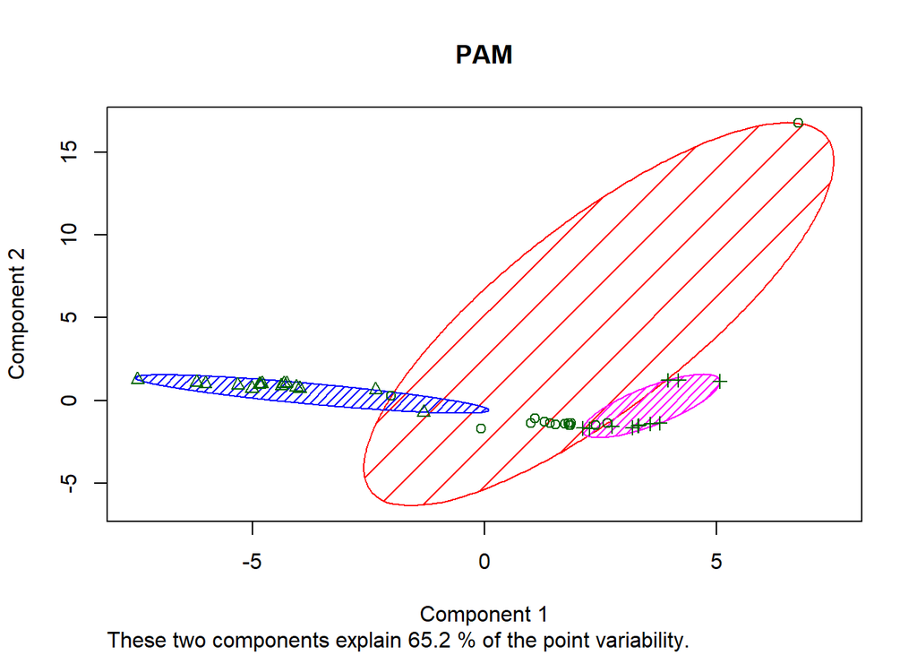

```r
clusplot(delta[,c(2:34)], gpe_pam$clustering,  lines = 0, color= T, shade= T,
         main = paste('PAM'))
```